# ECS230 Hw5

Eric Kalosa-Kenyon

08 December 2017

Abstract

In this assignment, I implement parts of PageRank.

# Brief proof of a property of eigenvalues

Let $A$ be a real $n\times n$ matrix and $\lambda$ an eigenvalue of $A$. Here, I show that $\lambda$ is an eigenvalue of $A^\top$ as well.

Notice that the eigenvalues of $A$ are the roots of its characteristic polynomial $f(\lambda) = det(A-\lambda I)$. Similarly, let $f^\top(\lambda) = det(A^\top-\lambda I)$ be the characteristic polynomial of the transposed matrix $A^\top$. This proof boils down to showing that $f(\lambda) = f^\top(\lambda)$ as follows:

1. $f(\lambda) = det(A-\lambda I)$
2. $det(A-\lambda I) = det((A-\lambda I)^\top)$
3. $det((A-\lambda I)^\top) = det(A^\top-\lambda I^\top)$
4. $det(A^\top-\lambda I^\top) = det(A^\top - \lambda I)$
5. $det(A^\top - \lambda I) = f^\top(\lambda) \quad \blacksquare$

Warrant for each of the steps in the proof above follow:

The first and final steps of the proof are the respective definitions of $f(\lambda)$ and $f^\top(\lambda)$. The second step can be seen by expanding $A-\lambda I$ into its $QR$ decomposition and using determinant product rules. The third and fourth steps are obvious.

# Power method

To solve for the dominant eigenvalue of a matrix $A$, the power method can be used. In short, the method is as follows:
$$b_{k+1} = \frac{Ab_k}{||Ab_k||}$$
This method and several extensions are implemented in the source code included at the end of this report.

## Reproducing a simple result

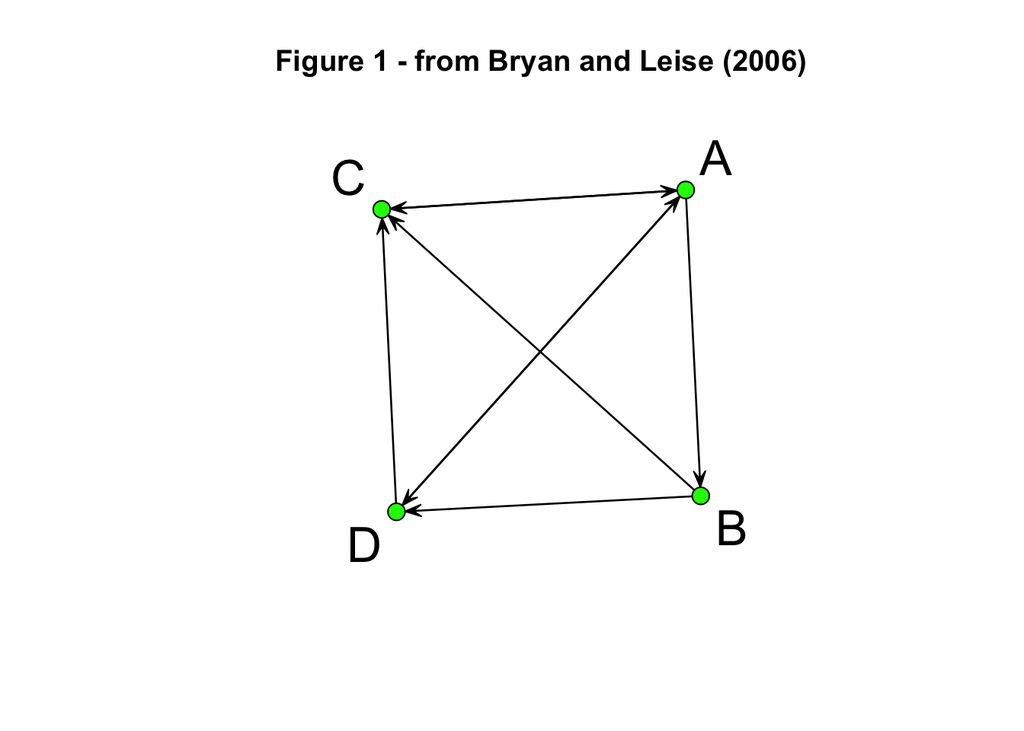

Using the graph presented in figure 1 of Bryan and Leise (2006), the program produes the following vector as the dominant L1-normalized eigenvector:
$$v_1 =
\left(
\begin{matrix}
0.387097 \\
0.129032 \\
0.290323 \\
0.193548
\end{matrix}
\right)$$
This solution is produced using the “bryan_leise_2006_fig1.dat” input file and corresponds to the ranking $A, C, D, B$.

## A PageRank manipulation strategy

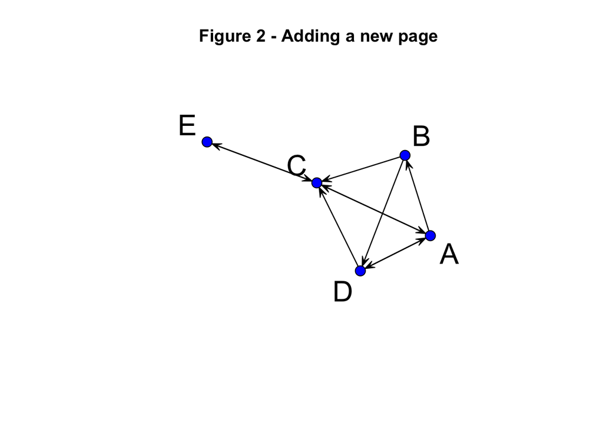

Using the strategy described in exercise 1 of Bryan and Leise where the owners of page $C$ make a new page $E$ and link both together, the dominant eigenvector becomes
$$v_2 =
\left(
\begin{matrix}
0.244898 \\
0.081633 \\
0.367347 \\
0.122449 \\
0.183673
\end{matrix}
\right)$$
This new dominant eigenvector $v_2$ corresponds to the ranking $C, A, E, D, B$. Notice that, using this strategy, the owners of page $3$ were able to manipulate the ranks.

## A chain graph and the shifted power method

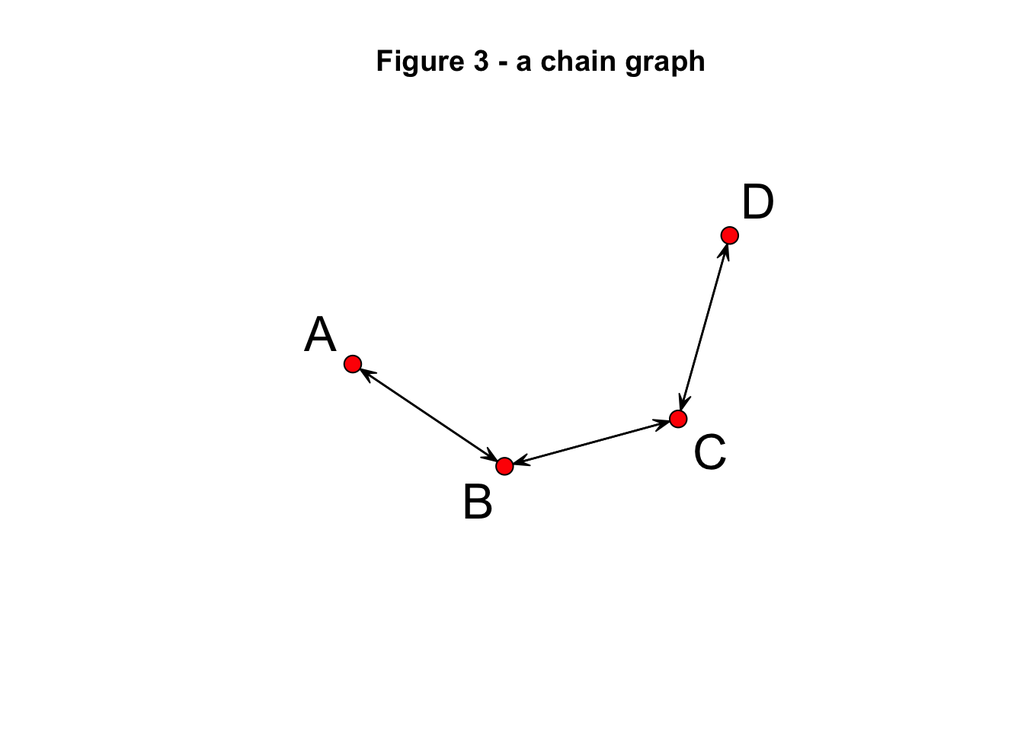

Using a chain graph of length $n=4$ and an initial vector
$$b_0 =
\left(
\begin{matrix}
1.000000 \\
1.000000 \\
1.000000 \\
1.000000
\end{matrix}
\right)$$

my program converges to the dominant eigenvector
$$v_3 =
\left(
\begin{matrix}
0.166667 \\
0.333333 \\
0.333333 \\
0.166667
\end{matrix}
\right)$$

corresponding to the ranking $\{2, 3\}, \{1, 4\}$ as expected. However, due to the fact that the spectrum of the induced matrix column-stochastic link matrix $A$ is
$$spec(A) = spec(
\left(
\begin{matrix}
0 & 1/2 & 0 & 0 \\
1 & 0 & 1/2 & 0 \\
0 & 1/2 & 0 & 1 \\
0 & 0 & 1/2 & 0
\end{matrix}
\right)
) = \{1, \frac{1}{2}, \frac{-1}{2}, -1\}$$

yielding two dominant eigenvectors corresponding to the eigenvalues $1$ and $-1$, the power method fails to converge for impropperly selected initial vectors. For example, when using
$$b_0 =
\left(
\begin{matrix}
1.00000 \\
2.00000 \\
3.00000 \\
4.00000
\end{matrix}
\right)$$

To solve this problem of non-convergence, I implement the shift method. In short, this replaces the matrix $A$ with $B=A+cI$ for some constant $c$. Note that the eigenvectors are identical for $A$ and $B$: if $v$ is an eigenvector of $A$, then $Bv=(A+cI)v=Av+cv=(\lambda+c)v$. Here, noting that the spectrum is bounded by $-1$ and $1$, I use $c=\frac{1}{4}$ to force the desired dominant eigenvector to have an eigenvalue of $1.25$ and bring the other eigenvectors away from dominance.

Upon implementation, the shifted power method converges for all tested initial vectors.

## Shifted power method vs. regularized power method

The shifted power method has already been discussed, so I’ll move forward assuming the reader understands it. The regularized power method is only slightly different, and I seek to illuminate the difference as follows: wheras; with the shifted method, the matrix $cI$ was added to $A$ in the form $B = A+cI$; in the regularized method, the matrix $\frac{1}{n}1_{n\times n}$ is added to $A$ in $B^\star=A+\frac{1}{n}1_{n\times n}$.

The merit of the shifted method is that the eigenvectors are invariant under this type of shift. The merit of the regularized method is that it may ensure the matrix $B^\star$ is well conditioned when data are limited and it guarantees a fully connected web.

The ranking of a linear chain would be invariant using either of the two methods discussed above. However, the regularized power method may suffer from underflow as $n\rightarrow\infty$. The shifted power method does not suffer from such an issue.

# Appendix

## Data

Following are the files used as inputs for the power_method program and their respective outputs. Each input represents a link matrix and follows the specification for .dat files given in the assignment handout: 1. The first line is a single integer $n$ stating the number of nodes in the graph. 2. Each subsequent line $j$ starts with an integer $n_j$ stating the number of outgoing links from page $j$. 3. On line $j$, after the initial $n_j$, each subsequent integer $i$ points to an external page $i$ to which page $j$ links.

bryan_leise_2006_fig1.dat:

```
input 4
input 3 2 3 4
input 2 3 4
input 1 1
input 2 1 3
```

```
output n=4
output
output A:
output 0.000000 0.000000 1.000000 0.500000
output 0.333333 0.000000 0.000000 0.000000
output 0.333333 0.500000 0.000000 0.500000
output 0.333333 0.500000 0.000000 0.000000
output
output b0:
output 0.500000
output 0.500000
output 0.500000
output 0.500000
output
output delta 0: 0.626224
output delta 1: 0.234651
output delta 2: 0.091438
output delta 3: 0.021550
output delta 4: 0.012705
output delta 5: 0.001872
output delta 6: 0.001299
output delta 7: 0.000343
output delta 8: 0.000112
output delta 9: 0.000056
output delta 10: 0.000009
output delta 11: 0.000007
output delta 12: 0.000001
output delta 13: 0.000001
output
output After 14 iterations to dominant eigenvector b:
output 0.387097
output 0.129032
output 0.290323
output 0.193548
output
output Converged successfully
```

ex1_add_pg_5.dat:

```
input 5
input 3 2 3 4
input 2 3 4
input 2 1 5
input 2 1 3
input 1 3
```

```
output n=5
output
output A:
output 0.000000 0.000000 0.500000 0.500000 0.000000
output 0.333333 0.000000 0.000000 0.000000 0.000000
output 0.333333 0.500000 0.000000 0.500000 1.000000
output 0.333333 0.500000 0.000000 0.000000 0.000000
output 0.000000 0.000000 0.500000 0.000000 0.000000
output
output b0:
output 0.447214
output 0.447214
output 0.447214
output 0.447214
output 0.447214
output
output delta 0: 1.004291
output delta 1: 0.555741
output delta 2: 0.199859
output delta 3: 0.066972
output delta 4: 0.022052
output delta 5: 0.009887
output delta 6: 0.003473
output delta 7: 0.001572
output delta 8: 0.000514
output delta 9: 0.000244
output delta 10: 0.000099
output delta 11: 0.000041
output delta 12: 0.000021
output delta 13: 0.000008
output delta 14: 0.000004
output delta 15: 0.000002
output delta 16: 0.000001
output
output After 17 iterations to dominant eigenvector b:
output 0.244898
output 0.081633
output 0.367347
output 0.122449
output 0.183673
output
output Converged successfully
```

lin_chain_len_4.dat:

```
input 4
input 1 2
input 2 1 3
input 2 2 4
input 1 3
```

using the initial vector $b_0=[1,1,1,1]$,

```
output n=4
output
output A:
output 0.000000 0.500000 0.000000 0.000000
output 1.000000 0.000000 0.500000 0.000000
output 0.000000 0.500000 0.000000 1.000000
output 0.000000 0.000000 0.500000 0.000000
output
output b0:
output 0.500000
output 0.500000
output 0.500000
output 0.500000
output
output delta 0: 0.742781
output delta 1: 0.133230
output delta 2: 0.027452
output delta 3: 0.005459
output delta 4: 0.001093
output delta 5: 0.000219
output delta 6: 0.000044
output delta 7: 0.000009
output delta 8: 0.000002
output delta 9: 0.000000
output
output After 10 iterations to dominant eigenvector b:
output 0.166667
output 0.333333
output 0.333333
output 0.166667
output
output Converged successfully
```

using the initial vector $b_0=[1,2,3,4]$,

```
output n=4
output
output A:
output 0.000000 0.500000 0.000000 0.000000
output 1.000000 0.000000 0.500000 0.000000
output 0.000000 0.500000 0.000000 1.000000
output 0.000000 0.000000 0.500000 0.000000
output
output b0:
output 0.182574
output 0.365148
output 0.547723
output 0.730297
output
output delta 0: 0.851257
output delta 1: 0.856173
output delta 2: 0.746241
output delta 3: 0.740509
output delta 4: 0.745419
output delta 5: 0.743439
output delta 6: 0.744553
output delta 7: 0.744026
output delta 8: 0.744297
output delta 9: 0.744163
output delta 10: 0.744231
output delta 11: 0.744197
output delta 12: 0.744214
output delta 13: 0.744206
output delta 14: 0.744210
output delta 15: 0.744208
output delta 16: 0.744209
output delta 17: 0.744208
output delta 18: 0.744208
output delta 19: 0.744208
output delta 20: 0.744208
output delta 21: 0.744208
output delta 22: 0.744208
output delta 23: 0.744208
output delta 24: 0.744208
output delta 25: 0.744208
```

[output cut: 75 more lines]

```
output
output Not converging fast enough
output breaking...
output
output Failed to converge
output After 101 iterations to vectors:
output 0.133333
output 0.400000
output 0.266667
output 0.200000
output and
output 0.372104
output 0.496139
output 0.744208
output 0.248069
```

using the initial vector $b_0=[1,2,3,4]$ and a shift of $c=\frac{1}{4}$,

```
output n=4
output
output A:
output 0.000000 0.500000 0.000000 0.000000
output 1.000000 0.000000 0.500000 0.000000
output 0.000000 0.500000 0.000000 1.000000
output 0.000000 0.000000 0.500000 0.000000
output
output b0:
output 0.182574
output 0.365148
output 0.547723
output 0.730297
output
output delta 0: 0.707992
output delta 1: 0.430785
output delta 2: 0.216914
output delta 3: 0.131508
output delta 4: 0.078594
output delta 5: 0.047182
output delta 6: 0.028323
output delta 7: 0.016995
output delta 8: 0.010198
output delta 9: 0.006119
output delta 10: 0.003671
output delta 11: 0.002203
output delta 12: 0.001322
output delta 13: 0.000793
output delta 14: 0.000476
output delta 15: 0.000285
output delta 16: 0.000171
output delta 17: 0.000103
output delta 18: 0.000062
output delta 19: 0.000037
output delta 20: 0.000022
output delta 21: 0.000013
output delta 22: 0.000008
output delta 23: 0.000005
output delta 24: 0.000003
output delta 25: 0.000002
output delta 26: 0.000001
output delta 27: 0.000001
output
output Converged successfully
output After 28 iterations to dominant eigenvector b:
output 0.166667
output 0.333333
output 0.333334
output 0.166667
```

## Source code

The following is the source used for the creation of this report. The code handed in on the CSIF computers is slightly different from the following source. The hand-in code conforms to the specifications of the assignment, wheras the following source is formatted to work with the project’s directory structure. No major algorithmic changes were made.

```
// Author: Eric Kalosa-Kenyon
//
// This program performs the power method to determine the leading eigenvector
// of a column-stochastic link matrix.
//
// Takes:
//      data.dat - input data (format not explicitly specified here)
// Returns:
//      StdIO - results
//
// Sources:

#include "stdio.h"
#include "stdlib.h"
#include "string.h"
#include "math.h"
#include "Accelerate/Accelerate.h"
// #include "cblas.h"

// BEGIN PROTOTYPES
void dgemm_(char * transa, char * transb, int * m, int * n, int * k,
    double * alpha, double * A, int * lda,
    double * B, int * ldb, double * beta,
    double *, int * ldc);

void dgemv_(char * trans, int * m, int * n,
    double * alpha, double * A, int * lda,
    double * x, int * incx, double * beta,
    double * y, int * incy);

int dpotrf_(char * uplo, int * n,
    double * A, int * lda, int * info);

void dtrsm_(char * side, char * uplo, char * transa, char * diag,
    int * m, int * n, double * alpha, double * A,
    int * lda, double * B, int * ldb);

/* double dnrm2_() */
// END PROTOTYPES

```

[output cut: 229 more lines]

```
        printf("and\n");
        for(i=0; i<n; i++){
            printf("%f\n", b2[i]);
        }
    }else{
        printf("\nConverged successfully\n");
        printf("After %d iterations to dominant eigenvector b:\n", itt);
        for(i=0; i<n; i++){
            printf("%f\n", b1[i]);
        }
    }

    return 0;
}
// END MAIN
```

```
# Author: Eric Kalosa-Kenyon
# Constructs and generates plots for the induced graphs in this assignment

## @knitr read_library

library(GGally)
library(network)

## @knitr graph1

a = matrix(0, 4, 4)
a[1,2] = 1;
a[1,3] = 1;
a[1,4] = 1;
a[2,3] = 1;
a[2,4] = 1;
a[3,1] = 1;
a[4,1] = 1;
a[4,3] = 1;
n = network(a, directed=T)
plot.network(n, label=c("A", "B", "C", "D"),
             arrowhead.cex=2, label.cex=2, vertex.cex=2,
             vertex.col="green")
title("Figure 1 - from Bryan and Leise (2006)")

## @knitr graph2

add.vertices(n, 1)
add.edge(n, 5, 3)
add.edge(n, 3, 5)

plot.network(n, label=c("A", "B", "C", "D", "E"),
             arrowhead.cex=2, label.cex=2, vertex.cex=2,
             vertex.col="blue")
title("Figure 2 - Adding a new page")

## @knitr graph3

a2 = matrix(0, 4, 4)
a2[1,2] = 1;
a2[2,1] = 1;
a2[2,3] = 1;
a2[3,2] = 1;
a2[3,4] = 1;
a2[4,3] = 1;
n2 = network(a2, directed=T)
plot.network(n2, label=c("A", "B", "C", "D"),
             arrowhead.cex=2, label.cex=2, vertex.cex=2,
             vertex.col="red")
title("Figure 3 - a chain graph")
```